# Network analysis and R Notebooks

Anders K. Krabberød

February 2020

### Prologue: R Notebooks

Try executing chunks by clicking the *Run* button within the chunk or by placing your cursor inside it and pressing *Cmd+Shift+Enter*.

# Networks in R

In this example we will look at networks generared with sparCC (Friedman and Alm, PLoS Com.Biol 2012). The SpiecEasi package contains a nice wrapper for running sparcc on phyloseq objects in R.

### Load necessary packages

First wee need to Load necessary packages, and install SpiecEasi if necessary.

```r
library(igraph)
library(phyloseq)
#library(devtools)
#install_github("zdk123/SpiecEasi")
library(SpiecEasi)
library(Matrix)
```

We also need to load the phyloseq object created by Dada2. Adjust the path if necessary.

```r
OsloFjord_phyloseq <- readRDS("OsloFjord_phyloseq.rds")
OsloFjord_phyloseq<-subset_samples(OsloFjord_phyloseq, sample_names(OsloFjord_phyloseq) != "S07")
OsloFjord_phyloseq<-subset_samples(OsloFjord_phyloseq, sample_names(OsloFjord_phyloseq) != "S09")

OsloFjord_phyloseq
```

```
phyloseq-class experiment-level object
otu_table()   OTU Table:         [ 593 taxa and 15 samples ]
sample_data() Sample Data:       [ 15 samples by 17 sample variables ]
tax_table()   Taxonomy Table:    [ 593 taxa by 8 taxonomic ranks ]
```

### Run sparCC

```r
system.time({
sparcc.samples <- sparcc(otu_table(OsloFjord_phyloseq), iter=200,inner_iter=100)
str(sparcc.samples)
})
```

[output not shown]

The sparcc object contains two list, the co-variance score and the correlation. In addition you should get boostrap and empirical p-values for the network. This takes some time, since the data is permutated and networks correlation scores are calculated may times over.

```
sparcc.samples.boot <- sparccboot(otu_table(OsloFjord_phyloseq), R =100, ncpu=4)
sparcc.samples.pval <- pval.sparccboot(OsloFjord.sparcc.samples.boot)
```

### Making a network of the correlation matrix

Turning the correlation values into a network requires a few steps.

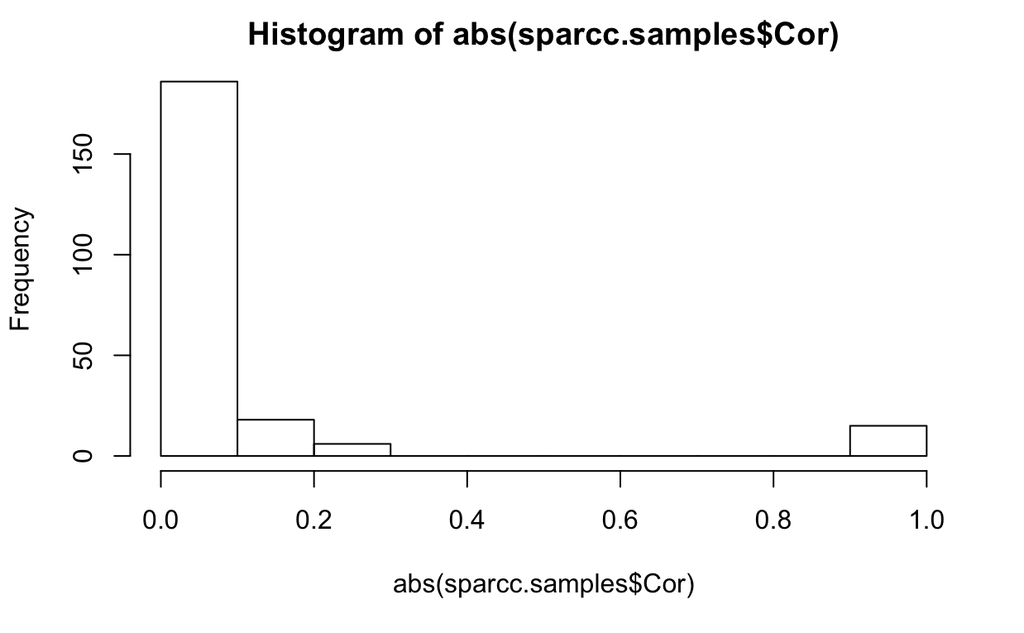

```r
row.names(sparcc.samples$Cor)<-row.names(sample_data(OsloFjord_phyloseq))
colnames(sparcc.samples$Cor)<-row.names(sample_data(OsloFjord_phyloseq))
hist(abs(sparcc.samples$Cor))
```

```r
## Define threshold for SparCC correlation matrix for the graph
sparcc.graph.matrix <- abs(sparcc.samples$Cor) >= 0.1
#sparcc.graph.matrix
diag(sparcc.graph.matrix) <- 0
sparcc.graph.matrix <- Matrix(sparcc.graph.matrix, sparse=TRUE)

# Create igraph objects from the adjacency matrix
sparcc.graph <- adj2igraph(sparcc.graph.matrix, vertex.attr = list(name=row.names(otu_table(t(OsloFjord_phyloseq)))))
```

### Graph statistics

```r
# How connected are the nodes?
degree(sparcc.graph)
```

```
S01 S02 S03 S04 S05 S06 S08 S10 S11 S12 S13 S14 S15 S16 S17
  4   1   1   3   2   3   3   1   2   0   2   0   0   0   2
```

```r
degree.distribution(sparcc.graph)
```

```
[1] 0.26666667 0.20000000 0.26666667 0.20000000 0.06666667
```

```r
# extract the correaltion score for the graph
elist.sparcc<- summary(sparcc.graph.matrix*sparcc.samples$Cor)
elist.sparcc
```

```
15 x 15 sparse Matrix of class "dsCMatrix", with 12 entries
   i  j         x
1  1  2 0.1465576
2  3  4 0.1211850
3  4  5 0.2289882
4  1  6 0.2128765
5  1  7 0.1919692
6  6  7 0.1522111
7  7  9 0.1854247
8  8  9 0.2390368
9  4 11 0.1236095
10 5 11 0.1865074
11 1 15 0.1365870
12 6 15 0.1361215
```

```r
cat("\nNetwork stats\n", "Clustering coefficient: ", ClusteringCcoefficient <- transitivity(sparcc.graph), "\n")
```

```
Network stats
 Clustering coefficient:  0.4736842
```

```r
cat("Betweenness entrality: ", BetweennessCentrality<- edge_betweenness(sparcc.graph),"\n")
```

```
Betweenness entrality:  6 2 7.5 3.5 3 2 2 1 4.5 2.5 10 6
```

```r
cat("Average path length: ", AveragePathLength <- average.path.length(sparcc.graph),"\n")
```

```
Average path length:  1.851852
```